# IODS course project

Mikael

# About the project

This all seems so confusing at first

*Write a short description about the course and add a link to your github repository here. This is an R markdown (.Rmd) file so you can use R markdown syntax. See the ‘Useful links’ page in the mooc area (chapter 1) for instructions.*

The course is all about exploring the possibilities of ODS and getting familiar with, as well as having fun

[My_repository](https://github.com/MikaelM76/IODS-project)

# Regression and model validation

*I have created an appropriate analysis dataset and excluded unwanted observations. Here we have analysis on the dataset and it’s variables.* - Describe your work and results clearly. - Assume the reader has an introductory course level understanding of writing and reading R code as well as statistical methods - Assume the reader has no previous knowledge of your data or the more advanced methods you are using

For these excercises the libraries “dplyr”, “ggplot2” and “GGally” are necessary. When reading the code these need to be installed and read. I have also included cache = F, since without it my version of R refused to knit the plots I made

1. First we read the dataset I created into R and explore its contents, dimensions and structure

```r
cache=F
 library("dplyr")
```

```r
library("ggplot2")
library("GGally")
library("lattice")
Students2014 <- read.table("~/Documents/IODS-project/data/learning2014/learning2014.txt", header = TRUE, sep = " ")
print(Students2014)
```

```
##     gender Age Attitude     deep  stra     surf Points
## 1        F  53       37 3.583333 3.375 2.583333     25
## 2        M  55       31 2.916667 2.750 3.166667     12
## 3        F  49       25 3.500000 3.625 2.250000     24
## 4        M  53       35 3.500000 3.125 2.250000     10
## 5        M  49       37 3.666667 3.625 2.833333     22
## 6        F  38       38 4.750000 3.625 2.416667     21
## 7        M  50       35 3.833333 2.250 1.916667     21
## 8        F  37       29 3.250000 4.000 2.833333     31
## 9        M  37       38 4.333333 4.250 2.166667     24
## 10       F  42       21 4.000000 3.500 3.000000     26
## 11       M  37       39 3.583333 3.625 2.666667     31
## 12       F  34       38 3.833333 4.750 2.416667     31
## 13       F  34       24 4.250000 3.625 2.250000     23
## 14       F  34       30 3.333333 3.500 2.750000     25
```

[output cut: 152 more lines]

```r
#2.
dim(Students2014)
```

```
## [1] 166   7
```

```r
str(Students2014)
```

```
## 'data.frame':    166 obs. of  7 variables:
##  $ gender  : Factor w/ 2 levels "F","M": 1 2 1 2 2 1 2 1 2 1 ...
##  $ Age     : int  53 55 49 53 49 38 50 37 37 42 ...
##  $ Attitude: int  37 31 25 35 37 38 35 29 38 21 ...
##  $ deep    : num  3.58 2.92 3.5 3.5 3.67 ...
##  $ stra    : num  3.38 2.75 3.62 3.12 3.62 ...
##  $ surf    : num  2.58 3.17 2.25 2.25 2.83 ...
##  $ Points  : int  25 12 24 10 22 21 21 31 24 26 ...
```

Second we display graphical implementation of the data

Overview:

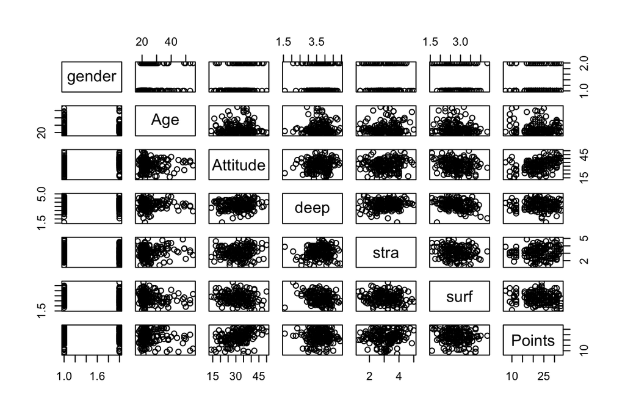

```r
plot(Students2014)
```

Results without variable ‘gender’: pairs(Students2014[-1])

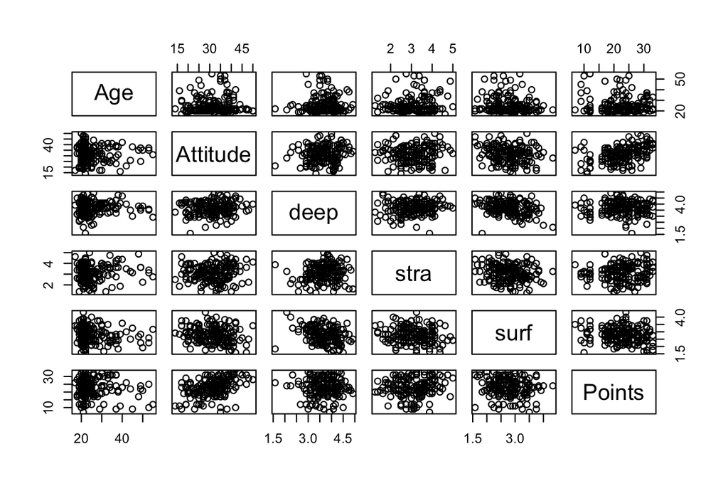

```r
pairs(Students2014[-1])
```

Last, a ggpairs-graphic for possibly a more clear display:

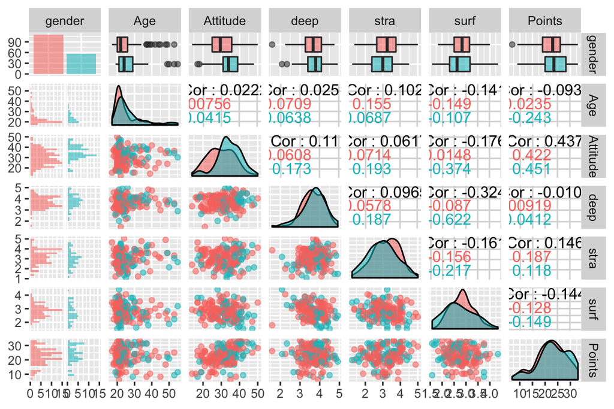

```r
ggpairs(Students2014, mapping = aes(col = gender, alpha = 0.3), lower = list(combo = wrap("facethist", bins = 20)))
```

Next we have summaries for the included variables and scatterplots to clarify their influence on the ‘points’ -variable:

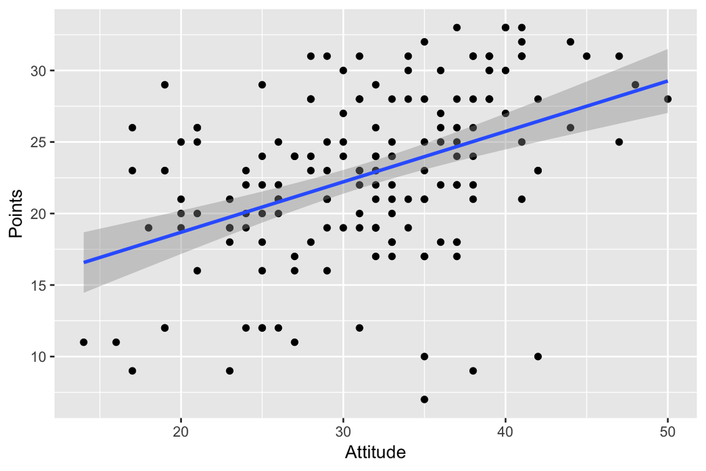

```r
library(ggplot2)
qplot(Attitude, Points, data = Students2014) + geom_smooth(method = "lm")
```

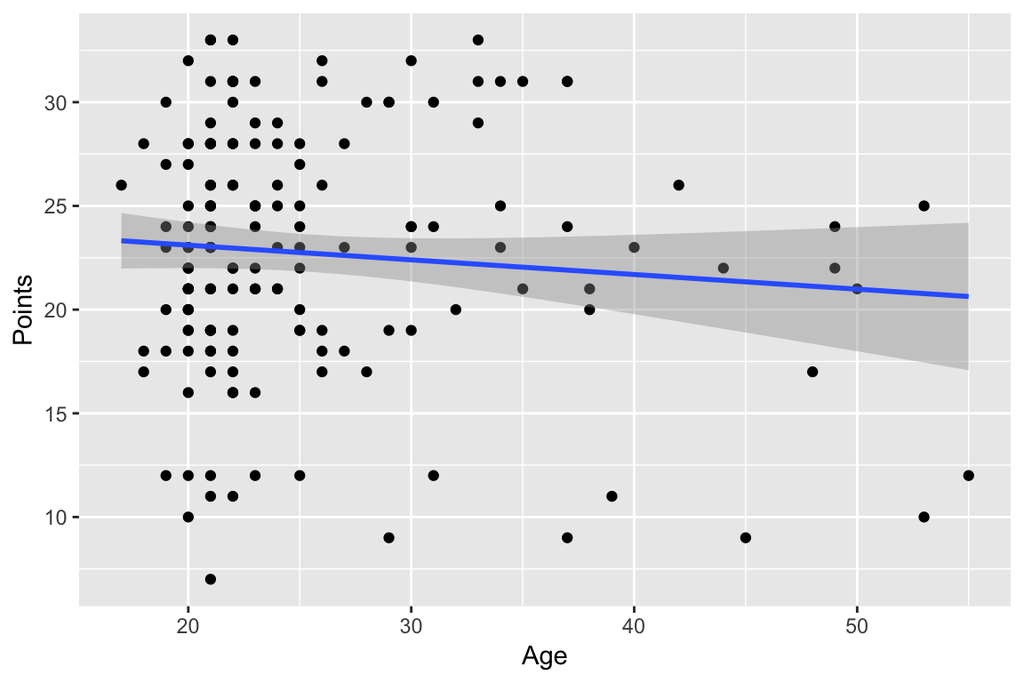

```r
qplot(Age, Points, data = Students2014) + geom_smooth(method = "lm")
```

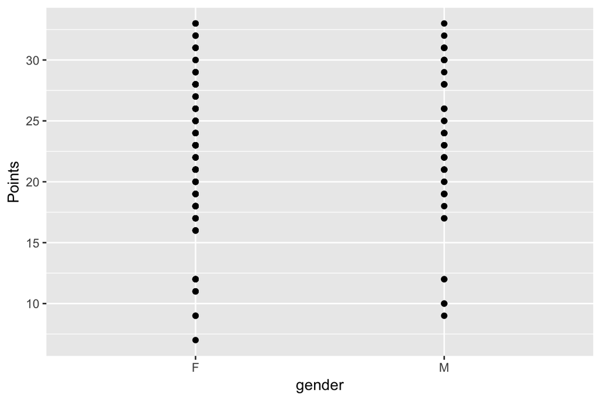

```r
qplot(gender, Points, data = Students2014) + geom_smooth(method = "lm")
```

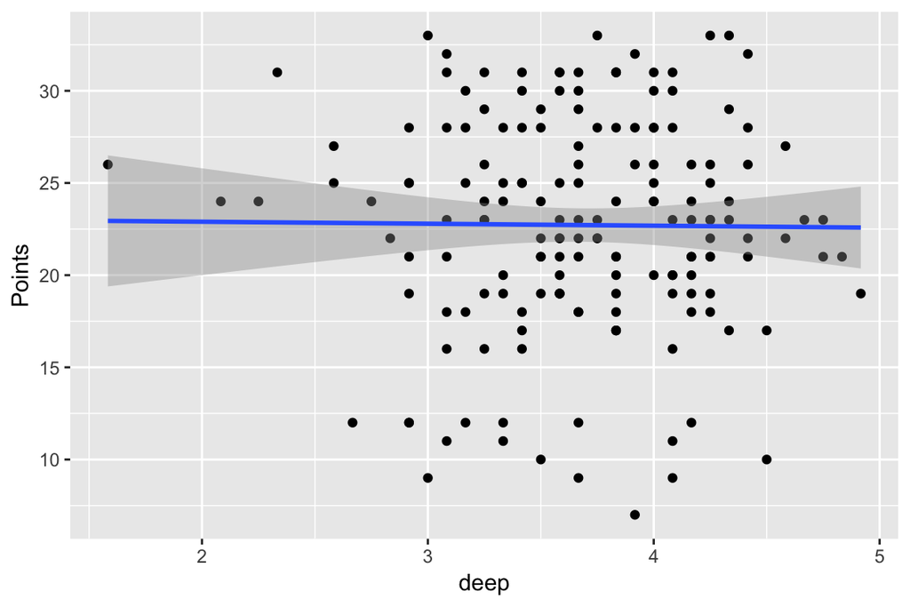

```r
qplot(deep, Points, data = Students2014) + geom_smooth(method = "lm")
```

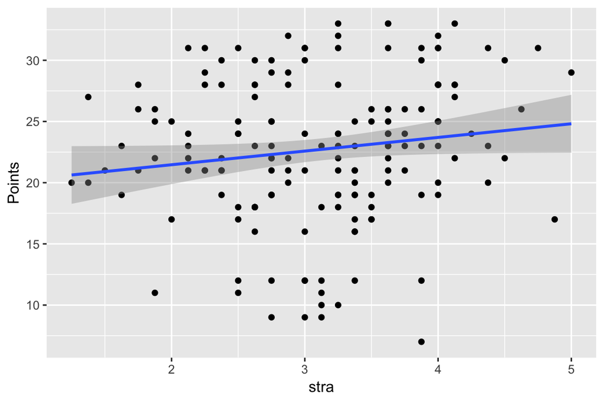

```r
qplot(stra, Points, data = Students2014) + geom_smooth(method = "lm")
```

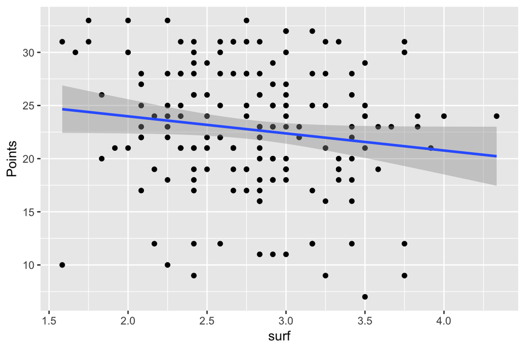

```r
qplot(surf, Points, data = Students2014) + geom_smooth(method = "lm")
```

Next some more illustration of the effects of the other variables to the ‘points’-variable and summaries of these

3. In the following simple regression models *Points* is used as the target variable while other variables are used as explanatory variables. There is also a summary provided for all of the individual regressions.

```r
M_Attitude <- lm(Points ~ Attitude, data = Students2014)
summary(M_Attitude)
```

```
##
## Call:
## lm(formula = Points ~ Attitude, data = Students2014)
##
## Residuals:
##      Min       1Q   Median       3Q      Max
## -16.9763  -3.2119   0.4339   4.1534  10.6645
##
## Coefficients:
##             Estimate Std. Error t value Pr(>|t|)
## (Intercept) 11.63715    1.83035   6.358 1.95e-09 ***
## Attitude     0.35255    0.05674   6.214 4.12e-09 ***
## ---
## Signif. codes:  0 '***' 0.001 '**' 0.01 '*' 0.05 '.' 0.1 ' ' 1
##
## Residual standard error: 5.32 on 164 degrees of freedom
## Multiple R-squared:  0.1906, Adjusted R-squared:  0.1856
## F-statistic: 38.61 on 1 and 164 DF,  p-value: 4.119e-09
```

```r
M_Age <- lm(Points ~ Age, data = Students2014)
summary(M_Age)
```

```
##
## Call:
## lm(formula = Points ~ Age, data = Students2014)
##
## Residuals:
##      Min       1Q   Median       3Q      Max
## -16.0360  -3.7531   0.0958   4.6762  10.8128
##
## Coefficients:
##             Estimate Std. Error t value Pr(>|t|)
## (Intercept) 24.52150    1.57339  15.585   <2e-16 ***
## Age         -0.07074    0.05901  -1.199    0.232
## ---
## Signif. codes:  0 '***' 0.001 '**' 0.01 '*' 0.05 '.' 0.1 ' ' 1
##
## Residual standard error: 5.887 on 164 degrees of freedom
## Multiple R-squared:  0.008684,   Adjusted R-squared:  0.00264
## F-statistic: 1.437 on 1 and 164 DF,  p-value: 0.2324
```

```r
M_gender <- lm(Points ~ gender, data = Students2014)
summary(M_gender)
```

```
##
## Call:
## lm(formula = Points ~ gender, data = Students2014)
##
## Residuals:
##      Min       1Q   Median       3Q      Max
## -15.3273  -3.3273   0.5179   4.5179  10.6727
##
## Coefficients:
##             Estimate Std. Error t value Pr(>|t|)
## (Intercept)  22.3273     0.5613  39.776   <2e-16 ***
## genderM       1.1549     0.9664   1.195    0.234
## ---
## Signif. codes:  0 '***' 0.001 '**' 0.01 '*' 0.05 '.' 0.1 ' ' 1
##
## Residual standard error: 5.887 on 164 degrees of freedom
## Multiple R-squared:  0.008632,   Adjusted R-squared:  0.002587
## F-statistic: 1.428 on 1 and 164 DF,  p-value: 0.2338
```

```r
M_deep <- lm(Points ~ deep, data = Students2014)
summary(M_deep)
```

```
##
## Call:
## lm(formula = Points ~ deep, data = Students2014)
##
## Residuals:
##      Min       1Q   Median       3Q      Max
## -15.6913  -3.6935   0.2862   4.9957  10.3537
##
## Coefficients:
##             Estimate Std. Error t value Pr(>|t|)
## (Intercept)  23.1141     3.0908   7.478 4.31e-12 ***
## deep         -0.1080     0.8306  -0.130    0.897
## ---
## Signif. codes:  0 '***' 0.001 '**' 0.01 '*' 0.05 '.' 0.1 ' ' 1
##
## Residual standard error: 5.913 on 164 degrees of freedom
## Multiple R-squared:  0.000103,   Adjusted R-squared:  -0.005994
## F-statistic: 0.01689 on 1 and 164 DF,  p-value: 0.8967
```

```r
M_stra <- lm(Points ~ stra, data = Students2014)
summary(M_stra)
```

```
##
## Call:
## lm(formula = Points ~ stra, data = Students2014)
##
## Residuals:
##      Min       1Q   Median       3Q      Max
## -16.5581  -3.8198   0.1042   4.3024  10.1394
##
## Coefficients:
##             Estimate Std. Error t value Pr(>|t|)
## (Intercept)   19.233      1.897  10.141   <2e-16 ***
## stra           1.116      0.590   1.892   0.0603 .
## ---
## Signif. codes:  0 '***' 0.001 '**' 0.01 '*' 0.05 '.' 0.1 ' ' 1
##
## Residual standard error: 5.849 on 164 degrees of freedom
## Multiple R-squared:  0.02135,    Adjusted R-squared:  0.01538
## F-statistic: 3.578 on 1 and 164 DF,  p-value: 0.06031
```

```r
M_surf <- lm(Points ~ surf, data = Students2014)
summary(M_surf)
```

```
##
## Call:
## lm(formula = Points ~ surf, data = Students2014)
##
## Residuals:
##      Min       1Q   Median       3Q      Max
## -14.6539  -3.3744   0.3574   4.4734  10.2234
##
## Coefficients:
##             Estimate Std. Error t value Pr(>|t|)
## (Intercept)  27.2017     2.4432  11.134   <2e-16 ***
## surf         -1.6091     0.8613  -1.868   0.0635 .
## ---
## Signif. codes:  0 '***' 0.001 '**' 0.01 '*' 0.05 '.' 0.1 ' ' 1
##
## Residual standard error: 5.851 on 164 degrees of freedom
## Multiple R-squared:  0.02084,    Adjusted R-squared:  0.01487
## F-statistic:  3.49 on 1 and 164 DF,  p-value: 0.06351
```

```r
sapply(Students2014, mean, na.rm = TRUE)
```

```
##    gender       Age  Attitude      deep      stra      surf    Points
##        NA 25.512048 31.427711  3.679719  3.121235  2.787149 22.716867
```

```r
sapply(Students2014, sd, na.rm = TRUE)
```

```
##    gender       Age  Attitude      deep      stra      surf    Points
## 0.4742358 7.7660785 7.2990794 0.5541369 0.7718318 0.5288405 5.8948836
```

```r
sapply(Students2014, var, na.rm = TRUE)
```

```
##     gender        Age   Attitude       deep       stra       surf
##  0.2248996 60.3119752 53.2765608  0.3070677  0.5957244  0.2796722
##     Points
## 34.7496532
```

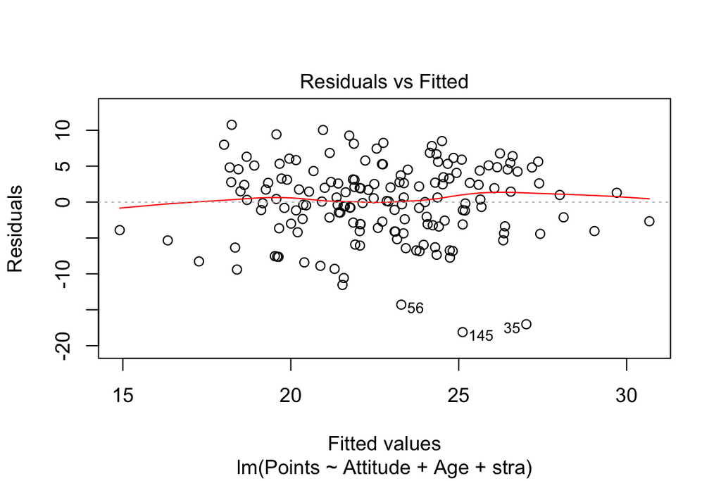

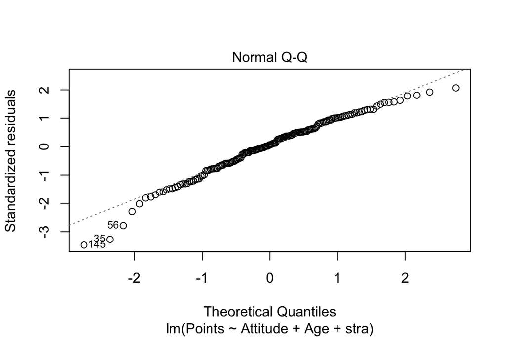

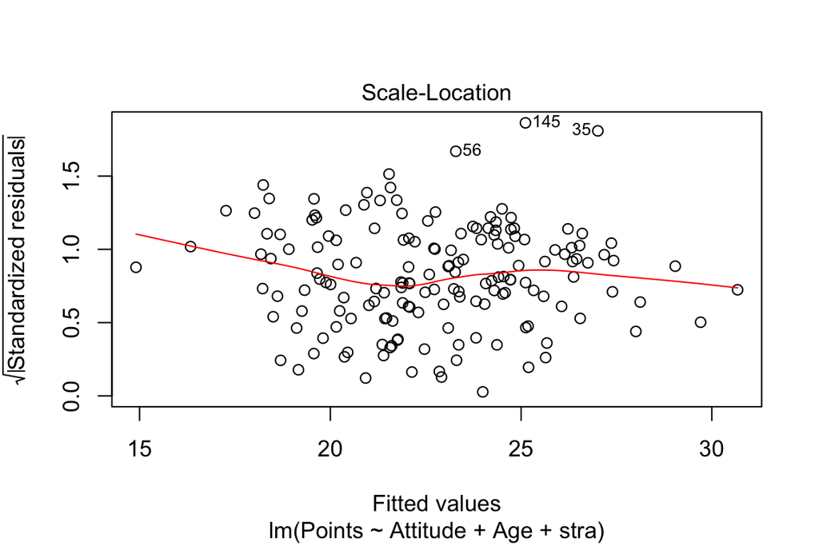

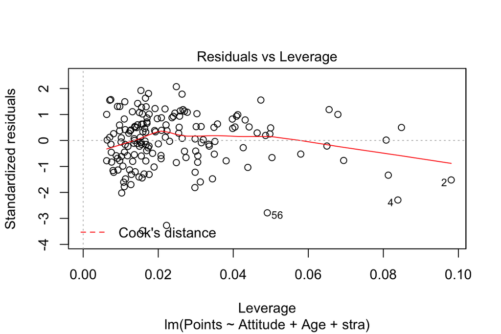

```r
Model3 <- lm(formula = Points ~ Attitude + Age + stra, data = Students2014)
plot(Model3)
```

The following functions work in my R-project, but for some reason they refused to knit to HTML. I have taken measures to enable the knitting of error terms etc, and it still won’t work. (I used these functions to make some interesting plots that I discuss later in the exercise. These were not individually necessary for ch2, and I have provided a collection of the mentioned plots in an other way also. This collection is included in the code). Still, I wanted to post them here to show what I did in another way. *Readers please note*: These were not as such demanded, and are provided in the necessary form later. If experimentation is done on them, I recommend copying them to an R-document, along with all the other necessary elements

*r.squared(Model3, model = NULL, type = c(“Attitude”, “Age”, “stra”), dfcor = TRUE)* #Normal Q-Q *r.squared(Model3, model = NULL, type = c(“Attitude”, “Age”, “stra”), dfcor = FALSE)* *r.squared(Model3, model = “lm”, type = c(“Attitude”, “Age”, “stra”), dfcor = TRUE)* #Res vs Lev *r.squared(Model3, model = “lm”, type = c(“Attitude”, “Age”, “stra”), dfcor = FALSE)* #Res vs Fit

4. Finally, a summary of the model:

```r
summary(Model3)
```

```
##
## Call:
## lm(formula = Points ~ Attitude + Age + stra, data = Students2014)
##
## Residuals:
##      Min       1Q   Median       3Q      Max
## -18.1149  -3.2003   0.3303   3.4129  10.7599
##
## Coefficients:
##             Estimate Std. Error t value Pr(>|t|)
## (Intercept) 10.89543    2.64834   4.114 6.17e-05 ***
## Attitude     0.34808    0.05622   6.191 4.72e-09 ***
## Age         -0.08822    0.05302  -1.664   0.0981 .
## stra         1.00371    0.53434   1.878   0.0621 .
## ---
## Signif. codes:  0 '***' 0.001 '**' 0.01 '*' 0.05 '.' 0.1 ' ' 1
##
## Residual standard error: 5.26 on 162 degrees of freedom
## Multiple R-squared:  0.2182, Adjusted R-squared:  0.2037
## F-statistic: 15.07 on 3 and 162 DF,  p-value: 1.07e-08
```

5. Next, three diagnostic plots are combined to help consider the validity of the model

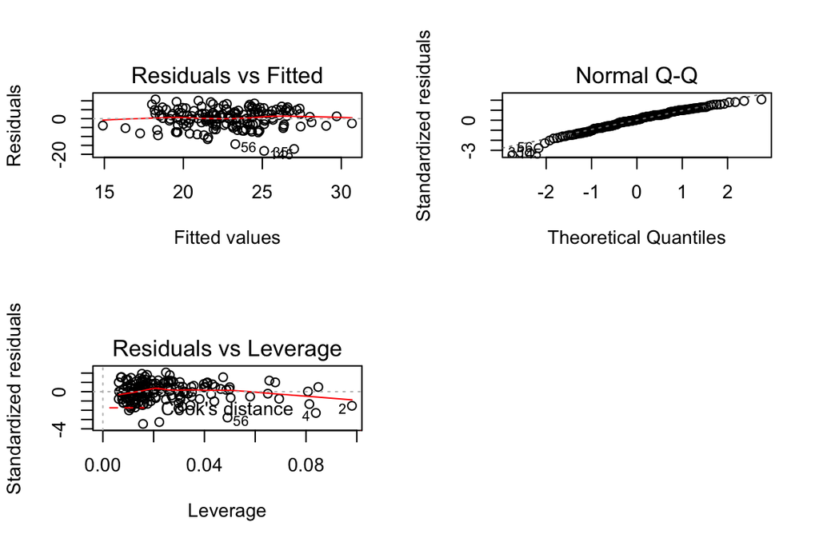

```r
par(mfrow = c(2,2))
plot(Model3, which = c(1,2,5))
```

Linear regression models have a few general assumtions: 1. Linearity 2. The errors of the model are normally distributed. 2. The errors are not correlated. 3. The sizes of the errors do not depend on the variables used to explain the target variable.

Now let’s think how the plots produced correspond (or not) to these assumption:

The Q–Q-plot demonstrates how the standardised residuals of the model fit to the theory or reasoning behind the model. Therefore the normal distribution assumption seems to be true for the model.

The residuals vs. fitted values -plot does not seem to be regular/subjected to any pattern, meaning that the errors are not correlated to the explanatory variables and their size is independent.

# Chapter 3 - Logistic Regression

There was a problem reading the file into R from my computer; The code worked but the data didn’t print out correctly, even though the same exact code combinations worked elsewhere, so I have included the necessary parts of the wrangling part to create the dataset again.

```r
cache=F
library(tidyr)
library(dplyr)
library(ggplot2)
library(gmodels)
```

```r
student_mat <-  read.csv("~/Documents/IODS-project/data/student-mat.csv", sep = ";")
student_por <- read.csv("~/Documents/IODS-project/data/student-por.csv", sep = ";")

join_by <- c("school","sex","age","address","famsize","Pstatus","Medu","Fedu","Mjob","Fjob","reason","nursery","internet")

math_por <- inner_join(student_mat, student_por, by = join_by, suffix = c(".student_mat", ".student_por"))

alc <- select(math_por, one_of(join_by))

notjoined_columns <- colnames(student_mat)[!colnames(student_mat) %in% join_by]


# for every column name not used for joining...
for(column_name in notjoined_columns) {
  # select two columns from 'math_por' with the same original name
  two_columns <- select(math_por, starts_with(column_name))
  # select the first column vector of those two columns
  first_column <- select(two_columns, 1)[[1]]

  # if that first column vector is numeric...
  if(is.numeric(first_column)) {
    # take a rounded average of each row of the two columns and
    # add the resulting vector to the alc data frame
    alc[column_name] <- round(rowMeans(two_columns))
  } else { # else if it's not numeric...
    # add the first column vector to the alc data frame
    alc[column_name] <- first_column
  }
}


alc <- mutate(alc, alc_use = (Dalc + Walc) / 2)
alc <- mutate(alc, high_use = alc_use > 2)
```

2. Let’s read the alc data. (This works but the original output wasn’t maintained from when I first wrote the code, as I explained)

```r
#alc <- read.csv("~/Documents/IODS-project/data/create_alc.R", row.names = NULL)
names(alc)
```

```
##  [1] "school"     "sex"        "age"        "address"    "famsize"
##  [6] "Pstatus"    "Medu"       "Fedu"       "Mjob"       "Fjob"
## [11] "reason"     "nursery"    "internet"   "guardian"   "traveltime"
## [16] "studytime"  "failures"   "schoolsup"  "famsup"     "paid"
## [21] "activities" "higher"     "romantic"   "famrel"     "freetime"
## [26] "goout"      "Dalc"       "Walc"       "health"     "absences"
## [31] "G1"         "G2"         "G3"         "alc_use"    "high_use"
```

3. For my variables, I chose sex, final exam scores, famsize and studytime. My hypotheses are as follows: Fewer females than males who took part consume a lot of alcohol. I would also assume that a person who doesn’t consume a lot of alcohol gets better grades than someone who drinks more.
4. Now we must test the hypothesis.

```r
alc %>% group_by(sex, high_use) %>%summarise(count=n(),mean_grade=mean(G3))
```

```
## # A tibble: 4 x 4
## # Groups:   sex [?]
##   sex   high_use count mean_grade
##   <fct> <lgl>    <int>      <dbl>
## 1 F     FALSE      156       11.4
## 2 F     TRUE        42       11.7
## 3 M     FALSE      112       12.2
## 4 M     TRUE        72       10.3
```

First we have the crosstabulation for alcohol usage, sex and the average of the final exam grades. The results of this tabulation tell us two things: i.) A higher percentage of men than women use alcohol a lot. ii.) Interestingly, those women who drink more have slightly higher grades. In contrast, binge-drinking men have worse grades than those who don’t drink a lot.

Then let’s create a boxplot of high alcohol usages effects to the final grades.

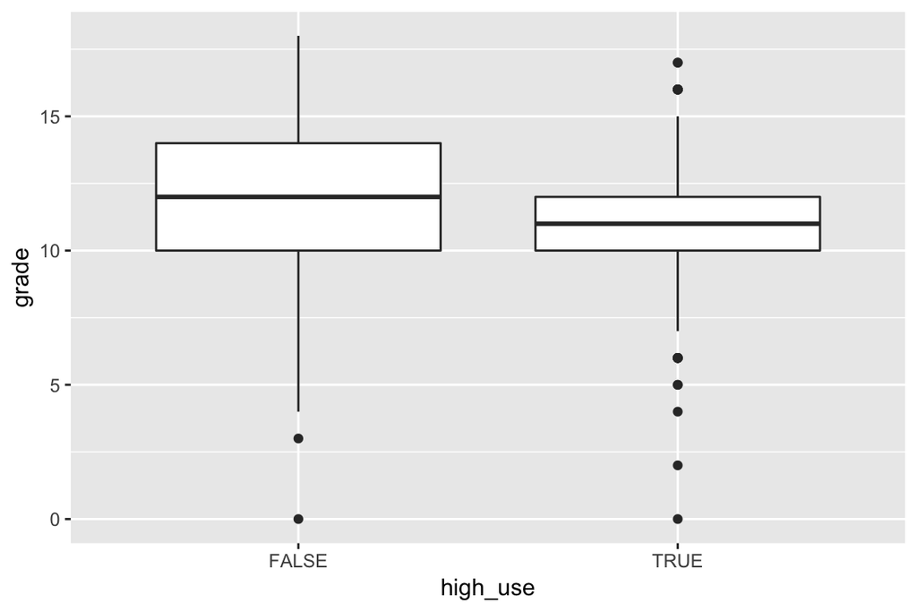

```r
g1 <- ggplot(alc, aes(x= high_use, y=G3), col=sex)
g1 + geom_boxplot()+ylab("grade")
```

It is clear that on average, alcohol-lovers have worse grades than moderate drinkers.

Then we have a barplot describing the relationship; alcohol usage vs. study time. Those who do not drink much are included in the darkred bar and those who drink a lot in the darkblue bar.

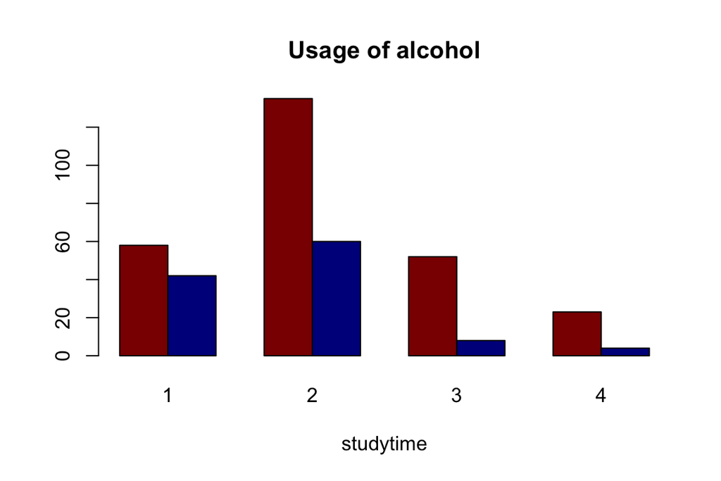

```r
counts <- table(alc$high_use, alc$studytime)
barplot(counts, main = "Usage of alcohol", xlab = "studytime", col = c("darkred", "darkblue"), beside = TRUE)
```

The key ratio described is the share of the drinkaholics in each category of study time. The shares are about equally small in 4 and 3 but get bigger in 2 and in 1 it is almost as common to drink a lot than not to drink a lot.

Then we compare alcohol usage to family size.

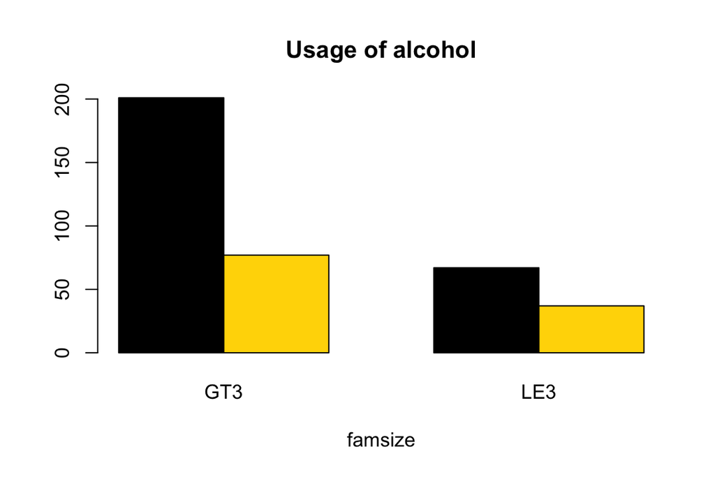

```r
counts2 <- table(alc$high_use, alc$famsize)
barplot(counts2, main = "Usage of alcohol", xlab = "famsize", col = c("black", "gold"), beside = TRUE)
```

The result is that students from small families, are somewhat more likely to drink a lot than those from big families.

5. The logistic regression describing our varibles follows.

```r
m <- glm(high_use ~ famsize + sex + G3 + studytime, data = alc, family = "binomial")
summary(m)
```

```
##
## Call:
## glm(formula = high_use ~ famsize + sex + G3 + studytime, family = "binomial",
##     data = alc)
##
## Deviance Residuals:
##     Min       1Q   Median       3Q      Max
## -1.4556  -0.8448  -0.6728   1.1674   2.1425
##
## Coefficients:
##             Estimate Std. Error z value Pr(>|z|)
## (Intercept)  0.36140    0.50827   0.711  0.47706
## famsizeLE3   0.31601    0.25722   1.229  0.21923
## sexM         0.67284    0.24445   2.752  0.00592 **
## G3          -0.07463    0.03598  -2.074  0.03806 *
## studytime   -0.41808    0.15933  -2.624  0.00869 **
## ---
## Signif. codes:  0 '***' 0.001 '**' 0.01 '*' 0.05 '.' 0.1 ' ' 1
##
## (Dispersion parameter for binomial family taken to be 1)
##
##     Null deviance: 465.68  on 381  degrees of freedom
## Residual deviance: 435.28  on 377  degrees of freedom
## AIC: 445.28
##
## Number of Fisher Scoring iterations: 4
```

Coefficients as odds ratios:

```r
OR <- coef(m) %>% exp
OR
```

```
## (Intercept)  famsizeLE3        sexM          G3   studytime
##   1.4353404   1.3716456   1.9598015   0.9280889   0.6583124
```

COnfidence intervals:

```r
CI <- confint(m) %>% exp
CI
```

```
##                 2.5 %    97.5 %
## (Intercept) 0.5317356 3.9213022
## famsizeLE3  0.8244681 2.2647911
## sexM        1.2165115 3.1774177
## G3          0.8641265 0.9954148
## studytime   0.4773416 0.8930376
```

```r
m <- glm(high_use ~ sex + studytime, data = alc, family = "binomial")
probabilities <- predict(m, type = "response")
alc <- mutate(alc, probability = probabilities)
alc <- mutate(alc, prediction = probability > 0.3)

select(alc, studytime, sex, high_use, probability, prediction) %>% tail(10)
```

```
##     studytime sex high_use probability prediction
## 373         1   M    FALSE   0.4795667       TRUE
## 374         1   M     TRUE   0.4795667       TRUE
## 375         3   F    FALSE   0.1536065      FALSE
## 376         1   F    FALSE   0.3222140       TRUE
## 377         3   F    FALSE   0.1536065      FALSE
## 378         2   F    FALSE   0.2270396      FALSE
## 379         2   F    FALSE   0.2270396      FALSE
## 380         2   F    FALSE   0.2270396      FALSE
## 381         1   M     TRUE   0.4795667       TRUE
## 382         1   M     TRUE   0.4795667       TRUE
```

```r
table(high_use = alc$high_use, prediction = alc$prediction)
```

```
##         prediction
## high_use FALSE TRUE
##    FALSE   158  110
##    TRUE     37   77
```

```r
CrossTable(alc$high_use, alc$prediction)
```

```
##
##
##    Cell Contents
## |-------------------------|
## |                       N |
## | Chi-square contribution |
## |           N / Row Total |
## |           N / Col Total |
## |         N / Table Total |
## |-------------------------|
##
##
## Total Observations in Table:  382
##
##
##              | alc$prediction
## alc$high_use |     FALSE |      TRUE | Row Total |
## -------------|-----------|-----------|-----------|
##        FALSE |       158 |       110 |       268 |
##              |     3.283 |     3.424 |           |
##              |     0.590 |     0.410 |     0.702 |
##              |     0.810 |     0.588 |           |
##              |     0.414 |     0.288 |           |
## -------------|-----------|-----------|-----------|
##         TRUE |        37 |        77 |       114 |
##              |     7.719 |     8.049 |           |
##              |     0.325 |     0.675 |     0.298 |
##              |     0.190 |     0.412 |           |
##              |     0.097 |     0.202 |           |
## -------------|-----------|-----------|-----------|
## Column Total |       195 |       187 |       382 |
##              |     0.510 |     0.490 |           |
## -------------|-----------|-----------|-----------|
##
##
```

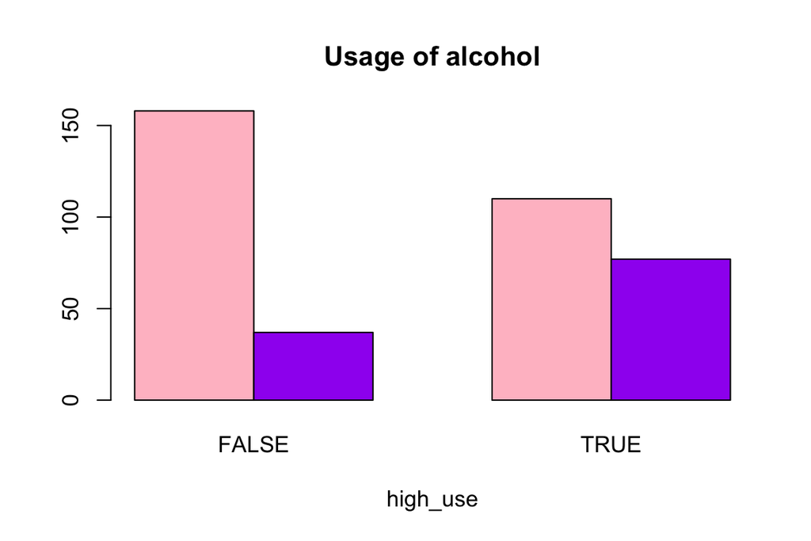

```r
counts3 <- table(alc$high_use, alc$prediction)
barplot(counts3, main = "Usage of alcohol", xlab = "high_use", col = c("pink", "purple"), beside = TRUE)
```

```r
g <- ggplot(alc, aes(x = probability, y = high_use, col = prediction))

g + geom_point()
```

[output not shown]

```r
table(high_use = alc$high_use, prediction = alc$prediction) %>% prop.table %>% addmargins
```

```
##         prediction
## high_use      FALSE       TRUE        Sum
##    FALSE 0.41361257 0.28795812 0.70157068
##    TRUE  0.09685864 0.20157068 0.29842932
##    Sum   0.51047120 0.48952880 1.00000000
```

```r
loss_func <- function(class, prob) {
  n_wrong <- abs(class - prob) > 0.5
  mean(n_wrong)
}

loss_func(class = alc$high_use, prob = 0)
```

```
## [1] 0.2984293
```

According to the results, the model provided provides a sense of reality, even if it it statistically not very reliable. By simply guessing what the results would be, the ideas that one comes up with could be similar but more accurate. What the model probably works for though, is that is offers some slight validation for any guesses made. Not much can be concluded from the model alone however, since the ratio of wrong predictions is quite large.

7. Here is ten-fold cross-validation of the model produced earlier. The average prediction error is higher than the one on datacamp. Let us see if one with a lower error can be found in Q8.

```r
library(boot)
cv <- cv.glm(data = alc, cost = loss_func, glmfit = m, K = 10)
cv$delta[1]
```

```
## [1] 0.3141361
```

8. Let us make and compare some different models. First there is a model that is slightly larger than the original one. Second, there is one with a lot more predictors. Next a smaller model with different variables than the original m.

```r
n <- glm(high_use ~ sex + studytime + famsize + failures + activities + absences, data = alc, family = "binomial")
probabilities <- predict(n, type = "response")

select(alc, studytime, sex, high_use, probability, prediction) %>% tail(10)
```

```
##     studytime sex high_use probability prediction
## 373         1   M    FALSE   0.4795667       TRUE
## 374         1   M     TRUE   0.4795667       TRUE
## 375         3   F    FALSE   0.1536065      FALSE
## 376         1   F    FALSE   0.3222140       TRUE
## 377         3   F    FALSE   0.1536065      FALSE
## 378         2   F    FALSE   0.2270396      FALSE
## 379         2   F    FALSE   0.2270396      FALSE
## 380         2   F    FALSE   0.2270396      FALSE
## 381         1   M     TRUE   0.4795667       TRUE
## 382         1   M     TRUE   0.4795667       TRUE
```

```r
table(high_use = alc$high_use, prediction = alc$prediction)
```

```
##         prediction
## high_use FALSE TRUE
##    FALSE   158  110
##    TRUE     37   77
```

```r
CrossTable(alc$high_use, alc$prediction)
```

```
##
##
##    Cell Contents
## |-------------------------|
## |                       N |
## | Chi-square contribution |
## |           N / Row Total |
## |           N / Col Total |
## |         N / Table Total |
## |-------------------------|
##
##
## Total Observations in Table:  382
##
##
##              | alc$prediction
## alc$high_use |     FALSE |      TRUE | Row Total |
## -------------|-----------|-----------|-----------|
##        FALSE |       158 |       110 |       268 |
##              |     3.283 |     3.424 |           |
##              |     0.590 |     0.410 |     0.702 |
##              |     0.810 |     0.588 |           |
##              |     0.414 |     0.288 |           |
## -------------|-----------|-----------|-----------|
##         TRUE |        37 |        77 |       114 |
##              |     7.719 |     8.049 |           |
##              |     0.325 |     0.675 |     0.298 |
##              |     0.190 |     0.412 |           |
##              |     0.097 |     0.202 |           |
## -------------|-----------|-----------|-----------|
## Column Total |       195 |       187 |       382 |
##              |     0.510 |     0.490 |           |
## -------------|-----------|-----------|-----------|
##
##
```

```r
g <- ggplot(alc, aes(x = probability, y = high_use, col = prediction))

g + geom_point()
```

[output not shown]

```r
table(high_use = alc$high_use, prediction = alc$prediction) %>% prop.table %>% addmargins
```

```
##         prediction
## high_use      FALSE       TRUE        Sum
##    FALSE 0.41361257 0.28795812 0.70157068
##    TRUE  0.09685864 0.20157068 0.29842932
##    Sum   0.51047120 0.48952880 1.00000000
```

```r
loss_func <- function(class, prob) {
  n_wrong <- abs(class - prob) > 0.5
  mean(n_wrong)
}

loss_func(class = alc$high_use, prob = 0)
```

```
## [1] 0.2984293
```

```r
cv <- cv.glm(data = alc, cost = loss_func, glmfit = m, K = 10)
cv$delta[1]
```

```
## [1] 0.2984293
```

```r
o <- glm(high_use ~ sex + studytime + famsize + failures + activities + absences + health + goout + freetime + romantic, data = alc, family = "binomial")
probabilities <- predict(o, type = "response")

select(alc, studytime, sex, high_use, probability, prediction) %>% tail(10)
```

```
##     studytime sex high_use probability prediction
## 373         1   M    FALSE   0.4795667       TRUE
## 374         1   M     TRUE   0.4795667       TRUE
## 375         3   F    FALSE   0.1536065      FALSE
## 376         1   F    FALSE   0.3222140       TRUE
## 377         3   F    FALSE   0.1536065      FALSE
## 378         2   F    FALSE   0.2270396      FALSE
## 379         2   F    FALSE   0.2270396      FALSE
## 380         2   F    FALSE   0.2270396      FALSE
## 381         1   M     TRUE   0.4795667       TRUE
## 382         1   M     TRUE   0.4795667       TRUE
```

```r
table(high_use = alc$high_use, prediction = alc$prediction)
```

```
##         prediction
## high_use FALSE TRUE
##    FALSE   158  110
##    TRUE     37   77
```

```r
CrossTable(alc$high_use, alc$prediction)
```

```
##
##
##    Cell Contents
## |-------------------------|
## |                       N |
## | Chi-square contribution |
## |           N / Row Total |
## |           N / Col Total |
## |         N / Table Total |
## |-------------------------|
##
##
## Total Observations in Table:  382
##
##
##              | alc$prediction
## alc$high_use |     FALSE |      TRUE | Row Total |
## -------------|-----------|-----------|-----------|
##        FALSE |       158 |       110 |       268 |
##              |     3.283 |     3.424 |           |
##              |     0.590 |     0.410 |     0.702 |
##              |     0.810 |     0.588 |           |
##              |     0.414 |     0.288 |           |
## -------------|-----------|-----------|-----------|
##         TRUE |        37 |        77 |       114 |
##              |     7.719 |     8.049 |           |
##              |     0.325 |     0.675 |     0.298 |
##              |     0.190 |     0.412 |           |
##              |     0.097 |     0.202 |           |
## -------------|-----------|-----------|-----------|
## Column Total |       195 |       187 |       382 |
##              |     0.510 |     0.490 |           |
## -------------|-----------|-----------|-----------|
##
##
```

```r
g <- ggplot(alc, aes(x = probability, y = high_use, col = prediction))

g + geom_point()
```

[output not shown]

```r
table(high_use = alc$high_use, prediction = alc$prediction) %>% prop.table %>% addmargins
```

```
##         prediction
## high_use      FALSE       TRUE        Sum
##    FALSE 0.41361257 0.28795812 0.70157068
##    TRUE  0.09685864 0.20157068 0.29842932
##    Sum   0.51047120 0.48952880 1.00000000
```

```r
loss_func <- function(class, prob) {
  n_wrong <- abs(class - prob) > 0.5
  mean(n_wrong)
}

loss_func(class = alc$high_use, prob = 0)
```

```
## [1] 0.2984293
```

```r
cv <- cv.glm(data = alc, cost = loss_func, glmfit = m, K = 10)
cv$delta[1]
```

```
## [1] 0.2984293
```

```r
p <- glm(high_use ~ failures + activities + absences + health + goout + freetime + romantic, data = alc, family = "binomial")
probabilities <- predict(p, type = "response")

select(alc, studytime, sex, high_use, probability, prediction) %>% tail(10)
```

```
##     studytime sex high_use probability prediction
## 373         1   M    FALSE   0.4795667       TRUE
## 374         1   M     TRUE   0.4795667       TRUE
## 375         3   F    FALSE   0.1536065      FALSE
## 376         1   F    FALSE   0.3222140       TRUE
## 377         3   F    FALSE   0.1536065      FALSE
## 378         2   F    FALSE   0.2270396      FALSE
## 379         2   F    FALSE   0.2270396      FALSE
## 380         2   F    FALSE   0.2270396      FALSE
## 381         1   M     TRUE   0.4795667       TRUE
## 382         1   M     TRUE   0.4795667       TRUE
```

```r
table(high_use = alc$high_use, prediction = alc$prediction)
```

```
##         prediction
## high_use FALSE TRUE
##    FALSE   158  110
##    TRUE     37   77
```

```r
CrossTable(alc$high_use, alc$prediction)
```

```
##
##
##    Cell Contents
## |-------------------------|
## |                       N |
## | Chi-square contribution |
## |           N / Row Total |
## |           N / Col Total |
## |         N / Table Total |
## |-------------------------|
##
##
## Total Observations in Table:  382
##
##
##              | alc$prediction
## alc$high_use |     FALSE |      TRUE | Row Total |
## -------------|-----------|-----------|-----------|
##        FALSE |       158 |       110 |       268 |
##              |     3.283 |     3.424 |           |
##              |     0.590 |     0.410 |     0.702 |
##              |     0.810 |     0.588 |           |
##              |     0.414 |     0.288 |           |
## -------------|-----------|-----------|-----------|
##         TRUE |        37 |        77 |       114 |
##              |     7.719 |     8.049 |           |
##              |     0.325 |     0.675 |     0.298 |
##              |     0.190 |     0.412 |           |
##              |     0.097 |     0.202 |           |
## -------------|-----------|-----------|-----------|
## Column Total |       195 |       187 |       382 |
##              |     0.510 |     0.490 |           |
## -------------|-----------|-----------|-----------|
##
##
```

```r
g <- ggplot(alc, aes(x = probability, y = high_use, col = prediction))

g + geom_point()
```

[output not shown]

```r
table(high_use = alc$high_use, prediction = alc$prediction) %>% prop.table %>% addmargins
```

```
##         prediction
## high_use      FALSE       TRUE        Sum
##    FALSE 0.41361257 0.28795812 0.70157068
##    TRUE  0.09685864 0.20157068 0.29842932
##    Sum   0.51047120 0.48952880 1.00000000
```

```r
loss_func <- function(class, prob) {
  n_wrong <- abs(class - prob) > 0.5
  mean(n_wrong)
}

loss_func(class = alc$high_use, prob = 0)
```

```
## [1] 0.2984293
```

```r
cv <- cv.glm(data = alc, cost = loss_func, glmfit = m, K = 10)
cv$delta[1]
```

```
## [1] 0.3062827
```